# MU 4 domaci zadatak

**student**: Veljko Milojevic

**broj indeksa**: 3066/2023

```python
import numpy as np
import pandas as pd
import matplotlib.pyplot as plt
```

```python
FIGSIZE = (12, 6)
DPI = 100
ALPHA = 0.4
RANDOM_STATE = 1
```

## Zadatak 1: Izbor prediktora

Za podatke iz *data_1.csv*, treba da sortirate prediktore od najboljeg do najgoreg, na 2 razlicita nacina:

1) na osnovu koeficijenata korelacije sa ciljnom promenljivom, 2) pomocu "omotac-algoritma", sa klasifikatorom po zelji.

Osmislite i nacrtajte grafik koji ilustruje kvalitete prediktora na po jednoj slici, za svaku od navedenih metoda.

```python
data = pd.read_csv('data_1.csv').to_numpy()
X = data[:, 0:-1]
y = data[:, -1]
```

### Korelacioni metod, korelacija sa ciljnom promenljivom

```python
n = X.shape[-1]
Rxy = np.empty(shape=(n,))
for i in range(n):
    Rxy[i] = abs(np.corrcoef(x=X[::, i], y=y)[1, 0])
print("Most important feature based on coefficient of correlation (feature with label): ", np.argsort(-Rxy)+1)
```

```
Most important feature based on coefficient of correlation (feature with label):  [13  1 10  7  6  4 12  5  3  8  9  2 11]
```

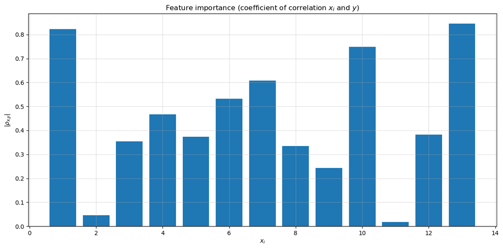

```python
plt.figure(figsize=FIGSIZE, dpi=DPI)
plt.bar(np.arange(n)+1, Rxy)
plt.xlabel("$x_i$")
plt.ylabel(r"$|\rho_{x_iy}|$")
plt.title("Feature importance (coefficient of correlation $x_i$ and $y$)")
plt.grid(alpha=ALPHA)
plt.tight_layout()
```

### "Omotac algoritam" (eng. Wraper algorithm)

```python
from sklearn.tree import DecisionTreeClassifier
from sklearn.model_selection import cross_val_score

selected_features = []
features_to_select = list(range(n))
selected_scores_mean = []
selected_scores_std = []
m = y.shape[-1]

while (len(features_to_select) != 0):
    val_scores_mean = []
    val_scores_std = []
    for i in features_to_select:
        model = DecisionTreeClassifier(random_state=RANDOM_STATE)
        X_train = []
        for j in selected_features:
            X_train.append(X[:, j].reshape(m, 1))

        X_train.append(X[:, i].reshape(m, 1))
        X_train = np.array(X_train).reshape(m, len(selected_features)+1)
        # fitting and scoring
        scores = cross_val_score(model, X_train, y, cv=10, scoring='f1')
        val_scores_mean.append(np.mean(scores))
        val_scores_std.append(np.std(scores))

    selected_feature = features_to_select[np.argmax(np.array(val_scores_mean))]
    selected_scores_mean.append(np.max(np.array(val_scores_mean)))
    selected_scores_std.append(np.max(np.array(val_scores_std)))
    selected_features.append(selected_feature)
    features_to_select.pop(np.argmax(np.array(val_scores_mean)))

selected_features = np.array(selected_features)
selected_scores_mean = np.array(selected_scores_mean)
sort_ind = np.argsort(np.array(selected_features))

print("Most important feature based on wrapper feature selection method: ", selected_features+1)
```

```
Most important feature based on wrapper feature selection method:  [13  1  2  3  7  5 12 10  8  4 11  9  6]
```

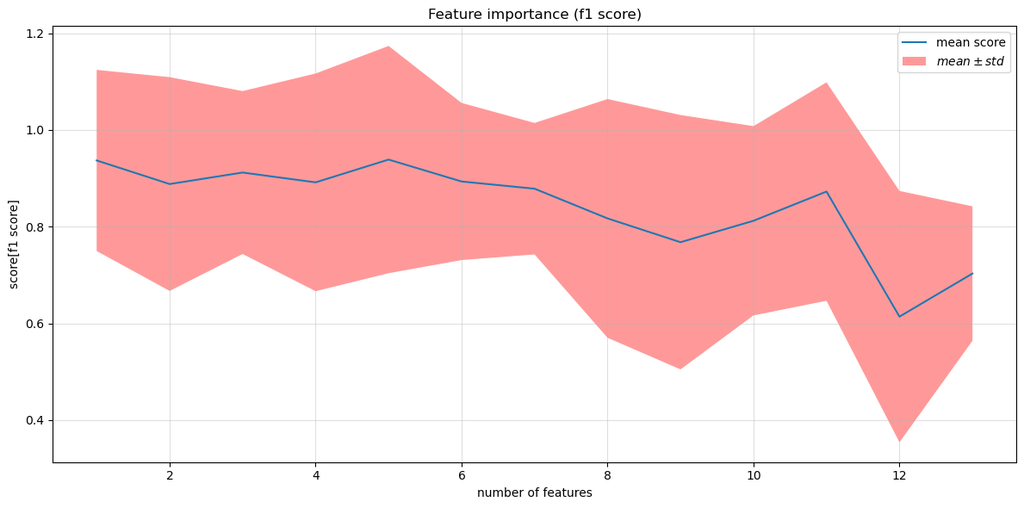

```python
plt.figure(figsize=FIGSIZE, dpi=DPI)
plt.plot(np.arange(n)+1, selected_scores_mean, label='mean score')
plt.fill_between(np.arange(n)+1, selected_scores_mean-selected_scores_std,
                 selected_scores_mean+selected_scores_std,facecolor='red',
                 alpha=ALPHA, label='$mean \\pm std$')
plt.xlabel("number of features")
plt.ylabel(r"score[f1 score]")
plt.title("Feature importance (f1 score)")
plt.grid(alpha=ALPHA)
plt.legend()

plt.tight_layout()
```

**KOMENTAR**: Rezultati primene obe metode su konzistentni oba algoritma su za dva najinformativnija prediktora izabrala $x_{13}$ i $x_1$.

## Zadatak 2: Obucavanje stabla

Za jedan par prediktora iz *data_1.csv* obucite klasifikaciono stablo. Dozvoljeno je koriscenje ugradenih f-ja i klasa: **sklearn.tree.DecisionTreeClassifier** u Pythonu, odnosno **ClassificationTree** u Matlabu.

Osmislite i nacrtajte grafike koji demonstriraju uticaj maksimalne dubine (ili maksimalnog broja cvorova, ako biblioteka koju koristite ne omogucava zadavanje maksimalne dubine) na kvalitet dobijenog modela. Treba da ilustrujete 3 razlicita slucaja: kada je model podobucen, kada je preobucen, i kada nije ni podobucen ni preobucen. Prikazite i granice odlucivanja u ravni prediktora za svaki od ova 3 slucaja.

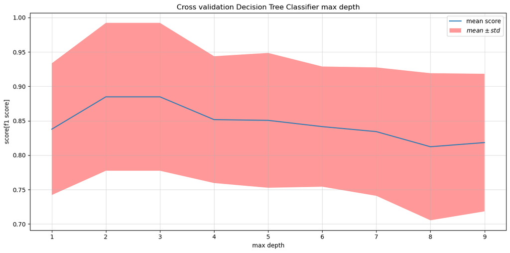

```python
from sklearn.model_selection import train_test_split
from sklearn.inspection import DecisionBoundaryDisplay

i1 = 8
i2 = 9

X_train, X_test, y_train, y_test = train_test_split(X[::, [i1, i2]],
                                                    y, random_state=RANDOM_STATE)

max_depth = [i for i in range(1,10)]

val_scores_mean = []
val_scores_std = []
for i in range(len(max_depth)):
    model = DecisionTreeClassifier(max_depth=max_depth[i], random_state=RANDOM_STATE)
    scores = cross_val_score(model, X_train, y_train, cv=10, scoring='f1')
    val_scores_mean.append(np.mean(scores))
    val_scores_std.append(np.std(scores))


max_depth = np.array(max_depth)
val_scores_mean = np.array(val_scores_mean)
val_scores_std = np.array(val_scores_std)

plt.figure(figsize=FIGSIZE, dpi=DPI)
plt.plot(max_depth, val_scores_mean, label='mean score')
plt.fill_between(max_depth, val_scores_mean-val_scores_std,
                 val_scores_mean+val_scores_std,facecolor='red',
                 alpha=ALPHA, label='$mean \\pm std$')
plt.xlabel("max depth")
plt.ylabel("score[f1 score]")
plt.title("Cross validation Decision Tree Classifier max depth")
plt.grid(alpha=ALPHA)
plt.legend()

plt.tight_layout()
```

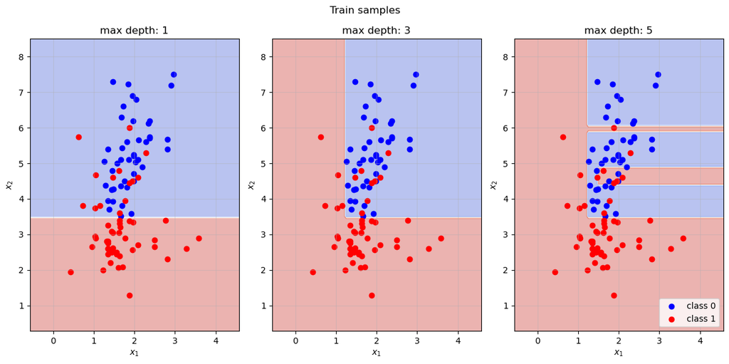

```python
#%% Plot for train set
max_depth = [1, 3, 5]


labels = np.unique(y)
plot_colors = "br"
plot_step = 0.02
n_classes = np.unique(y).shape[-1]
plt.figure(figsize=FIGSIZE, dpi=DPI)

for j in range(len(max_depth)):

    clf = DecisionTreeClassifier(max_depth=max_depth[j],  random_state=RANDOM_STATE)
    clf.fit(X_train, y_train)

    # Plot the decision boundary
    ax = plt.subplot(1,3,j+1)
    DecisionBoundaryDisplay.from_estimator(
        clf,
        X_train,
        cmap=plt.cm.coolwarm,
        response_method="predict",
        ax=ax,
        alpha = ALPHA
    )

    # Plot the training points
    for i, color in zip(range(n_classes), plot_colors):
        idx = np.where(y_train == i)
        plt.scatter(
            X_train[idx, 0],
            X_train[idx, 1],
            c=color,
            label= "class " + str(int(labels[i])),
        )

    ax.set_xlabel("$x_1$")
    ax.set_ylabel("$x_2$")
    ax.set_title("max depth: " + str(int(max_depth[j])))
    ax.grid(alpha=ALPHA)


plt.suptitle("Train samples")
plt.legend(loc="lower right")
plt.tight_layout()
```

Prikaz podobucavanja, dobro obucenog modela, i preobucenog modela na test skupu

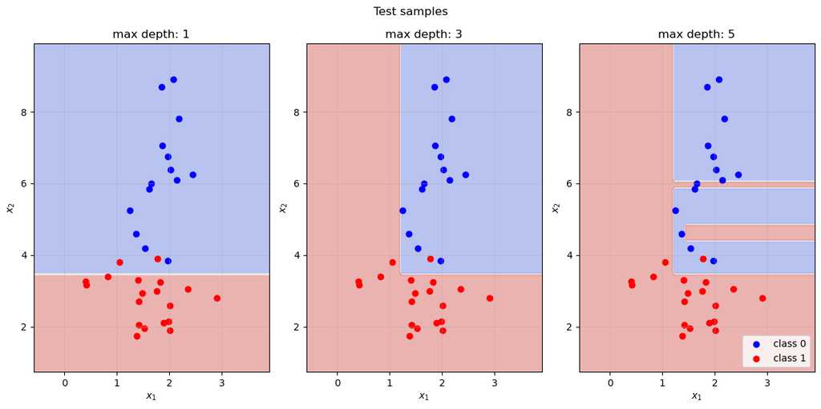

```python
#%% Plot for test set

max_depth = [1, 3, 5]

labels = np.unique(y)
plot_colors = "br"
plot_step = 0.02
n_classes = np.unique(y).shape[-1]
plt.figure(figsize=FIGSIZE, dpi=DPI)

for j in range(len(max_depth)):

    clf = DecisionTreeClassifier(max_depth=max_depth[j],  random_state=RANDOM_STATE)
    clf.fit(X_train, y_train)

    # Plot the decision boundary
    ax = plt.subplot(1,3,j+1)
    DecisionBoundaryDisplay.from_estimator(
        clf,
        X_test,
        cmap=plt.cm.coolwarm,
        response_method="predict",
        ax=ax,
        alpha = ALPHA
    )

    # Plot the test points
    for i, color in zip(range(n_classes), plot_colors):
        idx = np.where(y_test == i)
        plt.scatter(
            X_test[idx, 0],
            X_test[idx, 1],
            c=color,
            label= "class " + str(int(labels[i])),
        )

    ax.set_xlabel("$x_1$")
    ax.set_ylabel("$x_2$")
    ax.set_title("max depth: " + str(int(max_depth[j])))
    ax.grid(alpha=ALPHA)


plt.suptitle("Test samples")
plt.legend(loc="lower right")
plt.tight_layout()
```

## Zadatak 3: Ansambli

Na podacima iz *data_2.csv* ispitajte kako hiper-parametri uticu na performanse sledeca dva algoritama: 1) Random Forest (RF) 2) Gradient Boosting (GB).

U oba algoritma koristite stabla odlucivanja kao clanove ansambla. Dozvoljeno je koriscenje ugradenih f-ja za obucavanje klasifikatora: **fitcensemble (sa Method = ’LogitBoost’)** u Matlabu, odnosno **RandomForestClassifier** i **GradientBoostingClassifier** u Pyhon modulu sklearn.ensemble. Osmislite i nacrtajte grafike koji ilustruju uticaj hiper-parametara na kvalitet obucenog modela. Minimalan skup hiper-parametara koje treba da analizirate je

- velicina ansambla,
- velicina stabala,
- maksimalan broj odlika koji se razmatraju pri dodavanju cvora stabla (za RF),
- stopa ucenja (za GB).

Po zavrsenom treningu, graficki prikazite estimirane znacajnosti prediktora za bar jedan od dva analizirana algoritma.

```python
data = pd.read_csv('data_2.csv').to_numpy()
X = data[:, 0:-1]
y = data[:, -1]

X_train, X_test, y_train, y_test = train_test_split(X, y,
                                                    random_state=RANDOM_STATE)
```

### Random Forest Classifier

#### Velicina ansambla

```python
from sklearn.ensemble import RandomForestClassifier

max_ensemble_size = 100
step = 10

val_scores_mean = []
val_scores_std = []

for ensemble_size in range(1, max_ensemble_size, step):
    model = RandomForestClassifier(n_estimators=ensemble_size, random_state=RANDOM_STATE)
    scores = cross_val_score(model, X_train, y_train, cv=5, scoring='f1')
    val_scores_mean.append(np.mean(scores))
    val_scores_std.append(np.std(scores))
```

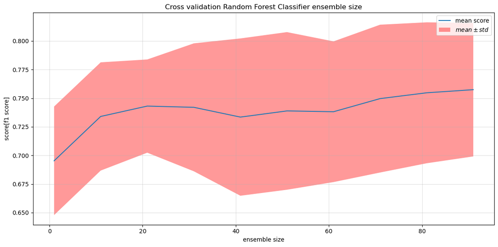

```python
val_scores_mean = np.array(val_scores_mean)
val_scores_std = np.array(val_scores_std)

plt.figure(figsize=FIGSIZE, dpi=DPI)
plt.plot(np.arange(1, max_ensemble_size, step=step), val_scores_mean, label='mean score')
plt.fill_between(np.arange(1, max_ensemble_size, step=step), val_scores_mean-val_scores_std,
                 val_scores_mean+val_scores_std,facecolor='red',
                 alpha=ALPHA, label='$mean \\pm std$')
plt.xlabel("ensemble size")
plt.ylabel("score[f1 score]")
plt.title("Cross validation Random Forest Classifier ensemble size")
plt.grid(alpha=ALPHA)
plt.legend()

plt.tight_layout()
```

```python
optimal_ensemble_size = 90
print("Optimal ensemble size: ", optimal_ensemble_size)
```

```
Optimal ensemble size:  90
```

#### Velicina stabla

```python
max_tree_depth = 30
step = 3
val_scores_mean = []
val_scores_std = []

for max_depth in range(1, max_tree_depth, step):
    model = RandomForestClassifier(n_estimators=optimal_ensemble_size, max_depth=max_depth, random_state=RANDOM_STATE)
    scores = cross_val_score(model, X_train, y_train, cv=5, scoring='f1')
    val_scores_mean.append(np.mean(scores))
    val_scores_std.append(np.std(scores))
```

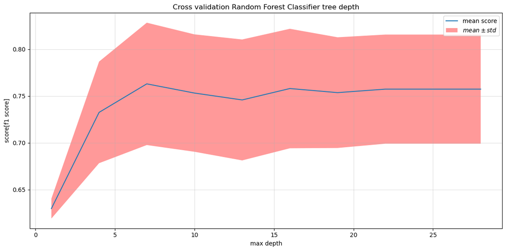

```python
val_scores_mean = np.array(val_scores_mean)
val_scores_std = np.array(val_scores_std)

plt.figure(figsize=FIGSIZE, dpi=DPI)
plt.plot(np.arange(1, max_tree_depth, step), val_scores_mean, label='mean score')
plt.fill_between(np.arange(1, max_tree_depth, step), val_scores_mean-val_scores_std,
                 val_scores_mean+val_scores_std,facecolor='red',
                 alpha=ALPHA, label='$mean \\pm std$')
plt.xlabel("max depth")
plt.ylabel("score[f1 score]")
plt.title("Cross validation Random Forest Classifier tree depth")
plt.grid(alpha=ALPHA)
plt.legend()

plt.tight_layout()
```

```python
optimal_max_depth = 7
print("Optimal tree depth: ", optimal_max_depth)
```

```
Optimal tree depth:  7
```

#### Maksimalan broj odlika koji se razmatraju pri dodavanju cvora stabla

```python
max_features_number = X.shape[-1]+1
step = 1
val_scores_mean = []
val_scores_std = []

for max_features in range(1, max_features_number, step):
    model = RandomForestClassifier(n_estimators=optimal_ensemble_size, max_features=max_features,
                                   max_depth=optimal_max_depth, random_state=RANDOM_STATE)
    scores = cross_val_score(model, X_train, y_train, cv=5, scoring='f1')
    val_scores_mean.append(np.mean(scores))
    val_scores_std.append(np.std(scores))
```

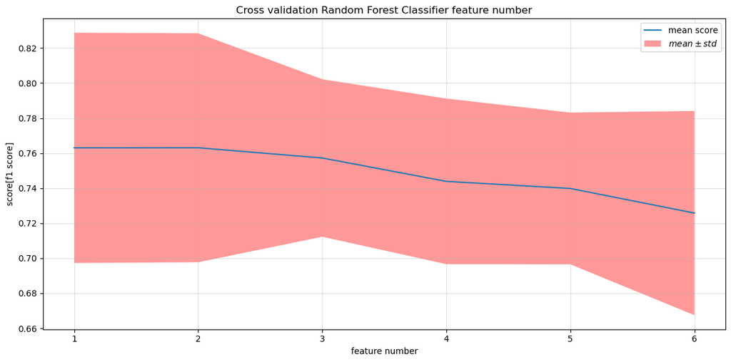

```python
val_scores_mean = np.array(val_scores_mean)
val_scores_std = np.array(val_scores_std)

plt.figure(figsize=FIGSIZE, dpi=DPI)
plt.plot(np.arange(1, max_features_number, step), val_scores_mean, label='mean score')
plt.fill_between(np.arange(1, max_features_number, step), val_scores_mean-val_scores_std,
                 val_scores_mean+val_scores_std,facecolor='red',
                 alpha=ALPHA, label='$mean \\pm std$')
plt.xlabel("feature number")
plt.ylabel("score[f1 score]")
plt.title("Cross validation Random Forest Classifier feature number")
plt.grid(alpha=ALPHA)
plt.legend()

plt.tight_layout()
```

```python
optimal_features_number = 2
print("Optimal feature number: ", optimal_features_number)
```

```
Optimal feature number:  2
```

#### Optimalan klasifikator - znacajnost prediktora

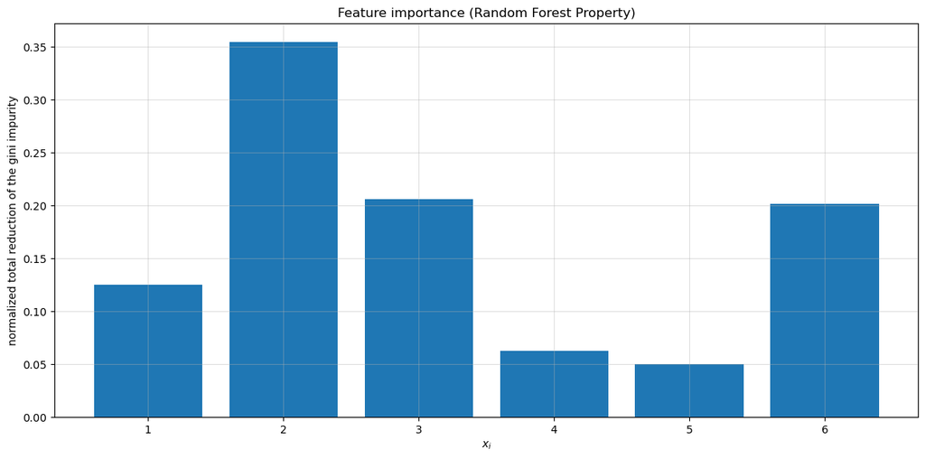

```python
model = RandomForestClassifier(n_estimators=optimal_ensemble_size, max_features=optimal_features_number,
                               max_depth=optimal_max_depth, random_state=RANDOM_STATE)
model.fit(X_train, y_train)

plt.figure(figsize=FIGSIZE, dpi=DPI)
plt.bar(np.arange(X.shape[-1])+1, model.feature_importances_)
plt.xlabel("$x_i$")
plt.ylabel("normalized total reduction of the gini impurity")
plt.title("Feature importance (Random Forest Property)")
plt.grid(alpha=ALPHA)
plt.tight_layout()
```

```python
print("Random Forest Classifier accuracy on test set: ", model.score(X_test, y_test))
```

```
Random Forest Classifier accuracy on test set:  0.8044692737430168
```

### Gradient Boosting

#### Velicina ansambla

```python
from sklearn.ensemble import GradientBoostingClassifier

max_ensemble_size = 200
step = 10

val_scores_mean = []
val_scores_std = []

for ensemble_size in range(1, max_ensemble_size, step):
    model = GradientBoostingClassifier(n_estimators=ensemble_size, random_state=RANDOM_STATE)
    scores = cross_val_score(model, X_train, y_train, cv=5, scoring='f1')
    val_scores_mean.append(np.mean(scores))
    val_scores_std.append(np.std(scores))
```

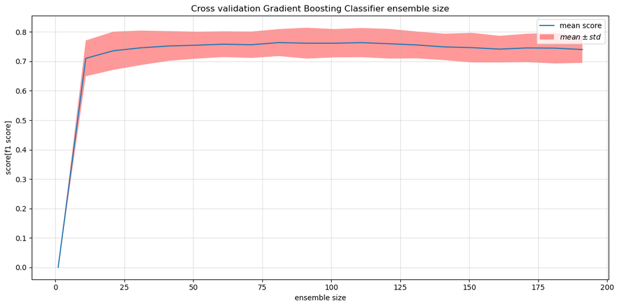

```python
val_scores_mean = np.array(val_scores_mean)
val_scores_std = np.array(val_scores_std)

plt.figure(figsize=FIGSIZE, dpi=DPI)
plt.plot(np.arange(1, max_ensemble_size, step=step), val_scores_mean, label='mean score')
plt.fill_between(np.arange(1, max_ensemble_size, step=step), val_scores_mean-val_scores_std,
                 val_scores_mean+val_scores_std,facecolor='red',
                 alpha=ALPHA, label='$mean \\pm std$')
plt.xlabel("ensemble size")
plt.ylabel("score[f1 score]")
plt.title("Cross validation Gradient Boosting Classifier ensemble size")
plt.grid(alpha=ALPHA)
plt.legend()

plt.tight_layout()
```

```python
optimal_ensemble_size = 30
print("Optimal ensemble size: ", optimal_ensemble_size)
```

```
Optimal ensemble size:  30
```

#### Velicina stabla

```python
max_tree_depth = 30
step = 3
val_scores_mean = []
val_scores_std = []

for max_depth in range(1, max_tree_depth, step):
    model = GradientBoostingClassifier(n_estimators=optimal_ensemble_size, max_depth=max_depth, random_state=RANDOM_STATE)
    scores = cross_val_score(model, X_train, y_train, cv=5, scoring='f1')
    val_scores_mean.append(np.mean(scores))
    val_scores_std.append(np.std(scores))
```

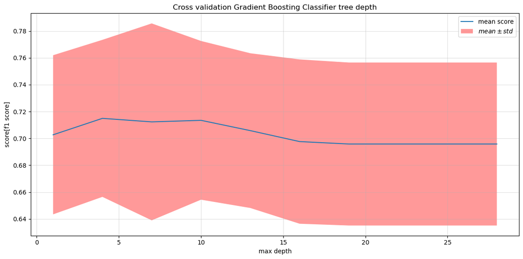

```python
val_scores_mean = np.array(val_scores_mean)
val_scores_std = np.array(val_scores_std)

plt.figure(figsize=FIGSIZE, dpi=DPI)
plt.plot(np.arange(1, max_tree_depth, step), val_scores_mean, label='mean score')
plt.fill_between(np.arange(1, max_tree_depth, step), val_scores_mean-val_scores_std,
                 val_scores_mean+val_scores_std,facecolor='red',
                 alpha=ALPHA, label='$mean \\pm std$')
plt.xlabel("max depth")
plt.ylabel("score[f1 score]")
plt.title("Cross validation Gradient Boosting Classifier tree depth")
plt.grid(alpha=ALPHA)
plt.legend()

plt.tight_layout()
```

```python
optimal_max_depth = 5
print("Optimal tree depth: ", optimal_max_depth)
```

```
Optimal tree depth:  5
```